# Project; Introduction to Probability and Data, Week 5

Masoud Asgharian Rostami

## Setup

### Load packages

```r
library(ggplot2)
library(dplyr)
library(corrplot)
```

### Load data

```r
load("brfss2013.RData")
```

## Part 1: Data

In this dataset, the sampling method was random and stratified sampling have been used to collect the data. Also, this is a observational study from different states in the USA that can be generalize to the whole population of world. However, no causality can be gain by this data. Also, this is very important when and what time these data collected, and it was good or bad day for the respondent.This is easily can effect the results and answers. Also, Number Of Days Physical and mental Health Not Good can be very bias respond because most of people dont remember.In addition, most of people lie in the questionnaire about Chronic Health Conditions, and they can cause big bias. Finally, although this dataset collected by the random phone numbers, the people are not selected to this experiment. Therfore, no causation can be determined by this dataset and we just can measure the correlation and association between the variables.

## Part 2: Research questions

**Research quesion 1:**

Are there any relationship between “general health, physical and mental health” with gender ‘sex’ and is there any association between sleep time and general health in Female and Male?

**Research quesion 2:**

In this question, we like to see whether "Employment status and Number Of Children in Household can effect the General health? Also, is there any association between Health Care Coverage and General health?

**Research quesion 3:**

Is there any relationship between Marital status, Education level and Income with general health?

## Part 3: Exploratory data analysis

### Research quesion 1

Lets explore the data:

```r
dim(brfss2013)
```

```
## [1] 491775    330
```

```r
str(brfss2013)
```

[output not shown]

[output cut: 86 more lines]

```r
names(brfss2013)
```

```
##   [1] "X_state"   "fmonth"    "idate"     "imonth"    "iday"
##   [6] "iyear"     "dispcode"  "seqno"     "X_psu"     "ctelenum"
##  [11] "pvtresd1"  "colghous"  "stateres"  "cellfon3"  "ladult"
##  [16] "numadult"  "nummen"    "numwomen"  "genhlth"   "physhlth"
##  [21] "menthlth"  "poorhlth"  "hlthpln1"  "persdoc2"  "medcost"
##  [26] "checkup1"  "sleptim1"  "bphigh4"   "bpmeds"    "bloodcho"
##  [31] "cholchk"   "toldhi2"   "cvdinfr4"  "cvdcrhd4"  "cvdstrk3"
##  [36] "asthma3"   "asthnow"   "chcscncr"  "chcocncr"  "chccopd1"
##  [41] "havarth3"  "addepev2"  "chckidny"  "diabete3"  "veteran3"
##  [46] "marital"   "children"  "educa"     "employ1"   "income2"
##  [51] "weight2"   "height3"   "numhhol2"  "numphon2"  "cpdemo1"
##  [56] "cpdemo4"   "internet"  "renthom1"  "sex"       "pregnant"
##  [61] "qlactlm2"  "useequip"  "blind"     "decide"    "diffwalk"
##  [66] "diffdres"  "diffalon"  "smoke100"  "smokday2"  "stopsmk2"
##  [71] "lastsmk2"  "usenow3"   "alcday5"   "avedrnk2"  "drnk3ge5"
```

[output cut: 51 more lines]

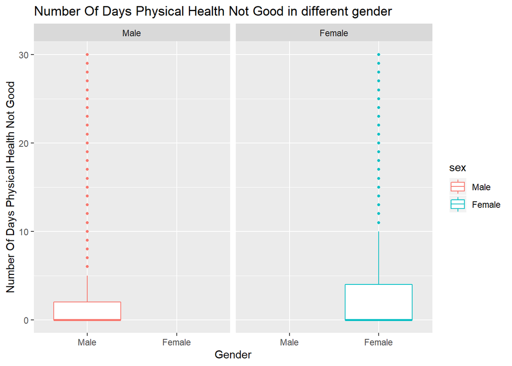

```r
brfss <- brfss2013 %>%filter(menthlth != "NA") %>% filter(physhlth != "NA")%>% filter(genhlth!= "NA") %>% filter(sleptim1 != "NA") %>% filter(sex != "NA")

ggplot(brfss , aes(x = sex, y =physhlth, color=sex )) + geom_boxplot(outlier.size = 1)+
  ggtitle("Number Of Days Physical Health Not Good in different gender")+xlab(" Gender ") +
  ylab("Number Of Days Physical Health Not Good")+facet_wrap(~sex)
```

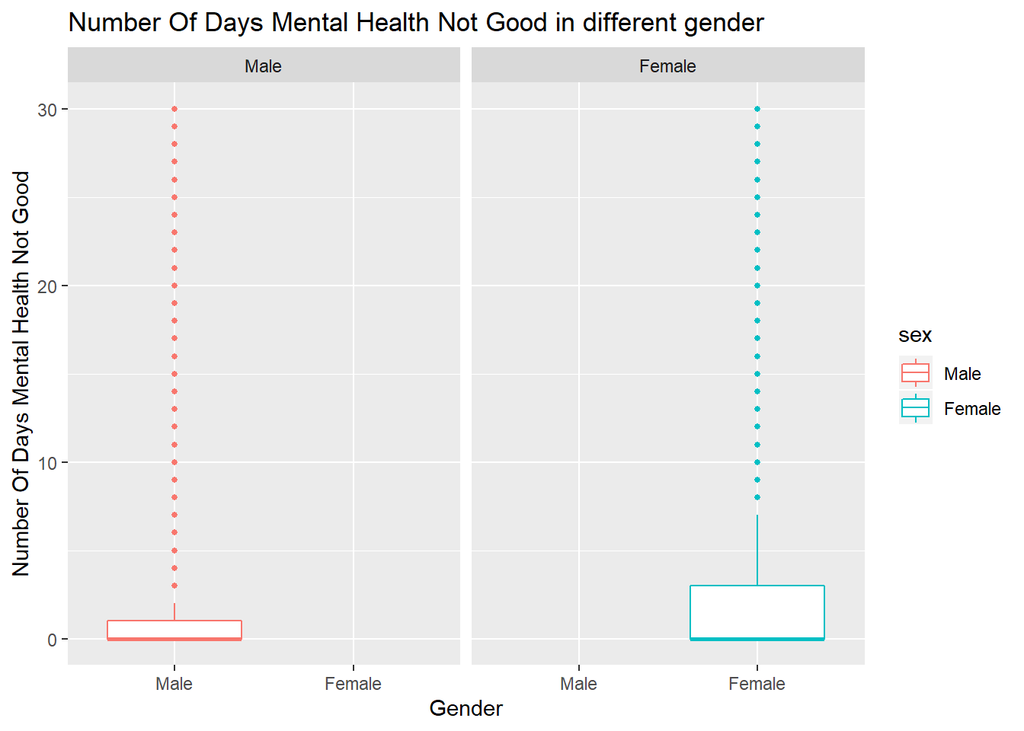

```r
ggplot(brfss , aes(x = sex, y =menthlth, color=sex )) + geom_boxplot(outlier.size = 1)+
  ggtitle("Number Of Days Mental Health Not Good in different gender")+xlab(" Gender ") +
  ylab("Number Of Days Mental Health Not Good")+facet_wrap(~sex)
```

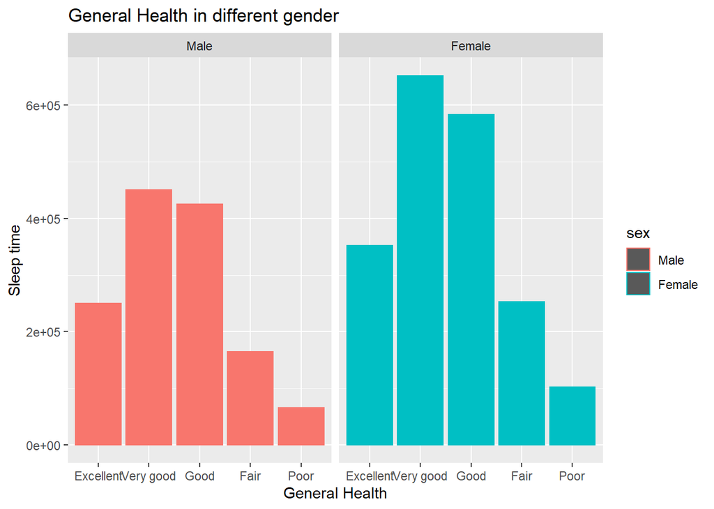

```r
ggplot(brfss , aes(x = genhlth, y =sleptim1, color=sex )) + geom_bar(stat = "identity")+
  ggtitle("General Health in different gender")+xlab("General Health") +
  ylab("Sleep time")+facet_wrap(~sex)
```

### Research quesion 2

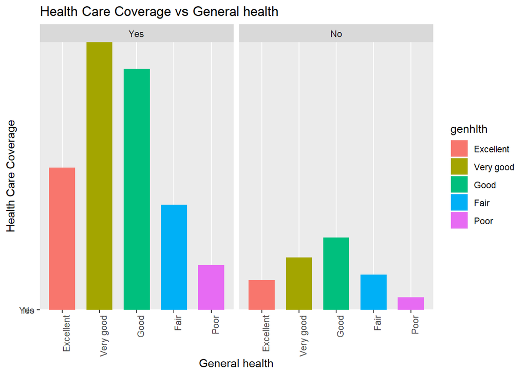

```r
brfss2 <- brfss2013 %>%filter(hlthpln1 != "NA") %>% filter(X_chldcnt != "NA")%>% filter(genhlth!= "NA") %>% filter(employ1 != "NA") %>% filter(sex != "NA")

ggplot(brfss2, aes(x = genhlth, y =hlthpln1, fill=genhlth )) + geom_bar(stat="identity", width=0.7)+
  ggtitle("Health Care Coverage vs General health")+
  xlab(" General health ") + ylab("Health Care Coverage")+ facet_wrap(~hlthpln1)+
  theme(axis.text.x = element_text(angle = 90, hjust = 1))
```

[figure not shown]

```r
ggplot(brfss2, aes(x = genhlth, y =X_chldcnt, fill=genhlth )) + geom_bar(stat="identity", width=0.7)+
  ggtitle("Number Of Children In Household vs General health")+
  xlab(" General health ") + ylab("Number Of Children In Household")+ facet_wrap(~sex)+
  theme(axis.text.x = element_text(angle = 90, hjust = 1))
```

[figure not shown]

```r
ggplot(brfss2, aes(x = genhlth, y =employ1, fill=genhlth )) + geom_bar(stat="identity", width=0.7)+
  ggtitle("Employment status vs General health")+
  xlab(" General health ") + ylab("Employment status")+ facet_wrap(~employ1)+
  theme(axis.text.x = element_text(angle = 90, hjust = 1))
```

### Research quesion 3

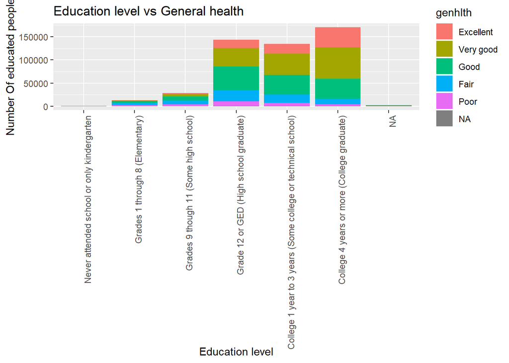

```r
ggplot(brfss2013)+geom_bar(aes(x=educa, fill=genhlth))+
  ggtitle("Education level vs General health")+
  xlab("Education level") + ylab("Number Of educated people")+theme(axis.text.x = element_text(angle = 90, hjust = 1))
```

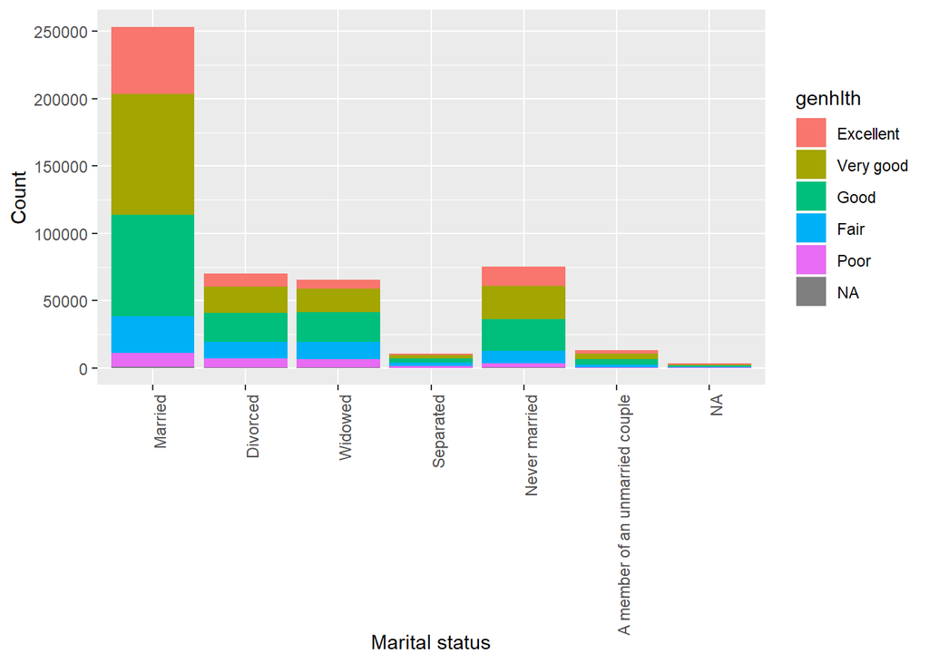

```r
ggplot(brfss2013)+geom_bar(aes(x=marital, fill=genhlth))+
  xlab("Marital status") + ylab("Count")+theme(axis.text.x = element_text(angle = 90, hjust = 1))
```

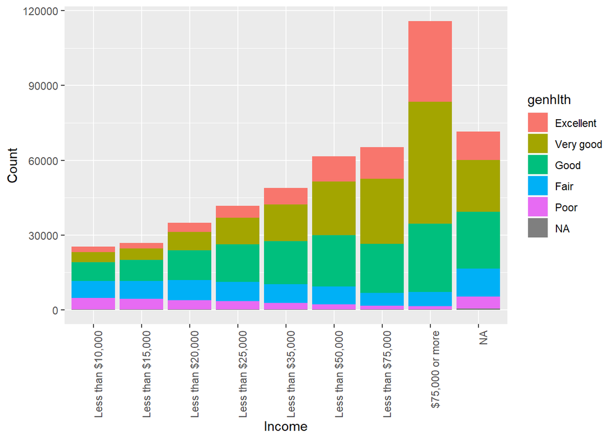

```r
ggplot(brfss2013)+geom_bar(aes(x=income2, fill=genhlth))+
  xlab("Income") + ylab("Count")+theme(axis.text.x = element_text(angle = 90, hjust = 1))
```

In case of income, people with higher income generally are healthier, so income is a critical variable. On the other hand, in case of Martial status, married people are healthier (Good, Very good and Excellent) compare to divorced, widowed and seperated people. In case of education, It seems cases with higher education are healthier that is very interesting finding.